# OI perception data QCA overview

Louise Shepperd

2022-10-30

### Introduction

This document offers an exploratory overview of QUALITATIVE data from the debrief questionnaire for the two language groups.This will also be explored in relation to participant demographic information and performance on the audiovisual matching task.

The research questions are as follows:

*RQ 2: What influence of written input are learners aware of regarding word learning?*

*2.1: What was the perceived influence of written input on their learning in the study?*

*2.2: What were participants’ beliefs around the importance of written input when learning new words more broadly?*

This document will explore each of these questions in turn.

### RQ 2.1 Perception of OI influence in the study

create diagram showing category hierarchy - can’t get this to work right noW!

```
## Multiple parents. Unfolding graph
##
##
## Multiple roots in graph. Choosing the first
```

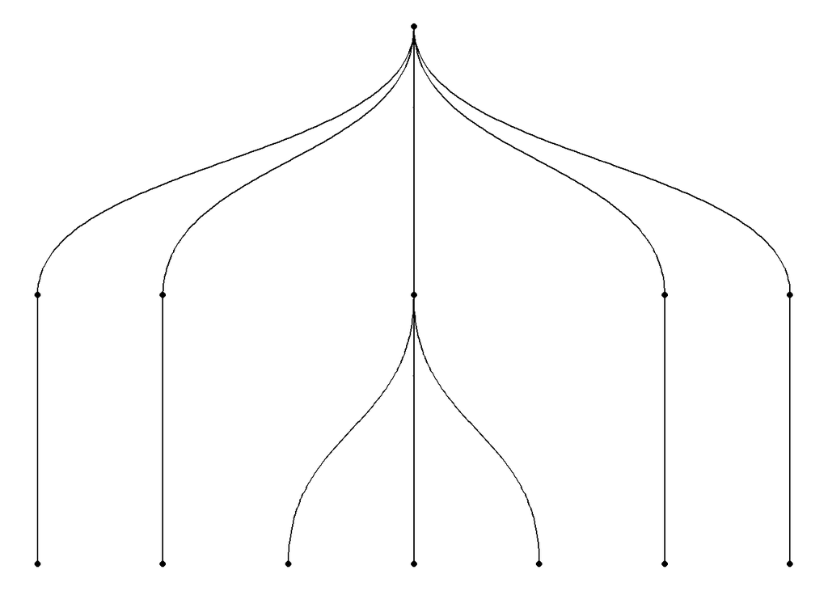

```r
categories<-data.frame(
  level1=c( rep("OI helps",7), rep("OI doesn't help",3)),
  level2=c( "learning", "remembering", rep("connect audio and visual input",3), "clarify what I heard", "rehearse words", "distracting (from sounds)", "better to ignore/focus on sounds", "unfamiliar"),
  level3=c( "", "focus on first letter", "visualise words", "map sounds to letters", "associate word and image", "differentiate similar sounds/words", "", "", "", ""))

# transform it to a edge list!
edges_level1_2 <- categories %>% select(level1, level2) %>% unique %>% rename(from=level1, to=level2)
edges_level2_3 <- categories %>% select(level2, level3) %>% unique %>% rename(from=level2, to=level3)
edge_list=rbind(edges_level1_2, edges_level2_3)

# Now we can plot that
mygraph <- graph_from_data_frame( edge_list )
ggraph(mygraph, layout = 'dendrogram', circular = FALSE) +
  geom_edge_diagonal() +
  geom_node_point()+
  theme_void()
```

#### Overall OI evaluation

create new dataset removing responses that couldn’t be coded for general evaluation of whether OI was helpful or not.

```r
OI_infl1 <- OI_infl_QCA %>%
  filter(general_influence1 != "")

summary(OI_infl_QCA$L1)
```

```
##  Arabic English
##     133     153
```

```r
summary(OI_infl1$L1)
```

```
##  Arabic English
##      75     132
```

Summary Statistics

| L1 Variable | Arabic N | Arabic Percent | English N | English Percent |
| --- | --- | --- | --- | --- |
| resp_lang1 | 75 |  | 132 |  |
| … | 0 | 0% | 0 | 0% |
| … Arabic | 35 | 46.7% | 0 | 0% |
| … English | 40 | 53.3% | 132 | 100% |
| general_influence1 | 75 |  | 132 |  |
| … | 0 | 0% | 0 | 0% |
| … doesn’t help | 21 | 28% | 41 | 31.1% |
| … helps | 54 | 72% | 91 | 68.9% |
| category1 | 75 |  | 132 |  |
| … | 16 | 21.3% | 16 | 12.1% |
| … better to ignore/ focus on sounds | 3 | 4% | 16 | 12.1% |
| … clarify what I heard | 8 | 10.7% | 33 | 25% |
| … connect audio and visual input (broadly) | 16 | 21.3% | 28 | 21.2% |
| … distracting (from sounds) | 2 | 2.7% | 4 | 3% |
| … learning (broadly) | 12 | 16% | 2 | 1.5% |
| … rehearse words | 0 | 0% | 5 | 3.8% |
| … remembering (broadly) | 18 | 24% | 23 | 17.4% |
| … unfamiliar | 0 | 0% | 5 | 3.8% |
| subcategory1 | 75 |  | 132 |  |
| … | 57 | 76% | 82 | 62.1% |
| … associate word and image | 6 | 8% | 11 | 8.3% |
| … differentiate similar sounds/ words | 6 | 8% | 20 | 15.2% |
| … focus on first letter | 0 | 0% | 8 | 6.1% |
| … map sounds and letters | 4 | 5.3% | 7 | 5.3% |
| … visualise words | 2 | 2.7% | 4 | 3% |

create another new dataset removing responses that couldn’t be coded for specific type of OI influence.

```r
OI_infl2 <- OI_infl1 %>%
  filter(category1 != "")

OI_influence_tb2 <- select(OI_infl2,resp_lang1, general_influence1, category1,subcategory1, L1)

st(OI_influence_tb2, group = "L1")
```

Summary Statistics

| L1 Variable | Arabic N | Arabic Percent | English N | English Percent |
| --- | --- | --- | --- | --- |
| resp_lang1 | 59 |  | 116 |  |
| … | 0 | 0% | 0 | 0% |
| … Arabic | 28 | 47.5% | 0 | 0% |
| … English | 31 | 52.5% | 116 | 100% |
| general_influence1 | 59 |  | 116 |  |
| … | 0 | 0% | 0 | 0% |
| … doesn’t help | 5 | 8.5% | 25 | 21.6% |
| … helps | 54 | 91.5% | 91 | 78.4% |
| category1 | 59 |  | 116 |  |
| … | 0 | 0% | 0 | 0% |
| … better to ignore/ focus on sounds | 3 | 5.1% | 16 | 13.8% |
| … clarify what I heard | 8 | 13.6% | 33 | 28.4% |
| … connect audio and visual input (broadly) | 16 | 27.1% | 28 | 24.1% |
| … distracting (from sounds) | 2 | 3.4% | 4 | 3.4% |
| … learning (broadly) | 12 | 20.3% | 2 | 1.7% |
| … rehearse words | 0 | 0% | 5 | 4.3% |
| … remembering (broadly) | 18 | 30.5% | 23 | 19.8% |
| … unfamiliar | 0 | 0% | 5 | 4.3% |
| subcategory1 | 59 |  | 116 |  |
| … | 41 | 69.5% | 66 | 56.9% |
| … associate word and image | 6 | 10.2% | 11 | 9.5% |
| … differentiate similar sounds/ words | 6 | 10.2% | 20 | 17.2% |
| … focus on first letter | 0 | 0% | 8 | 6.9% |
| … map sounds and letters | 4 | 6.8% | 7 | 6% |
| … visualise words | 2 | 3.4% | 4 | 3.4% |

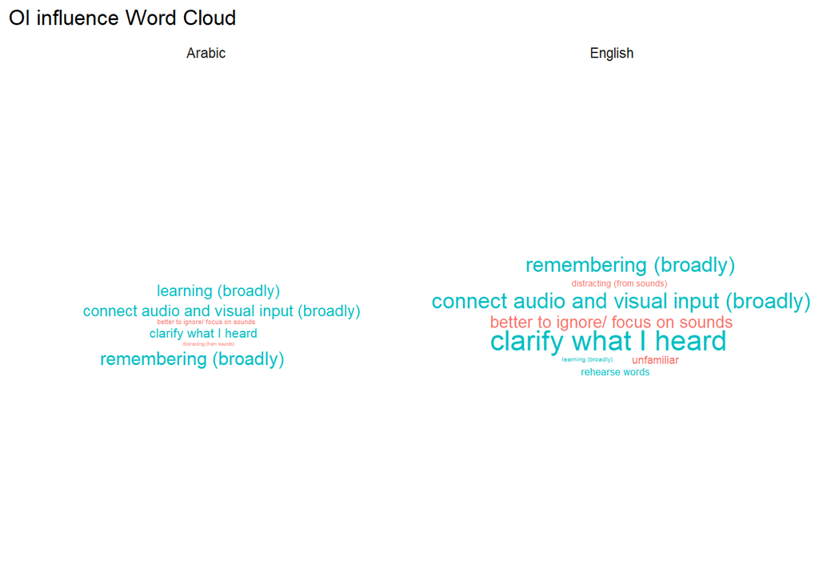

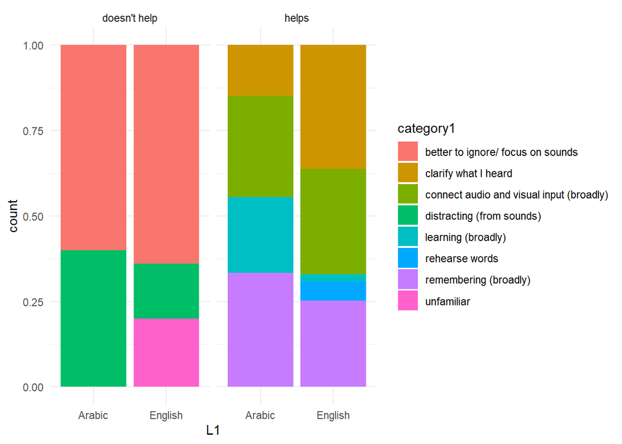

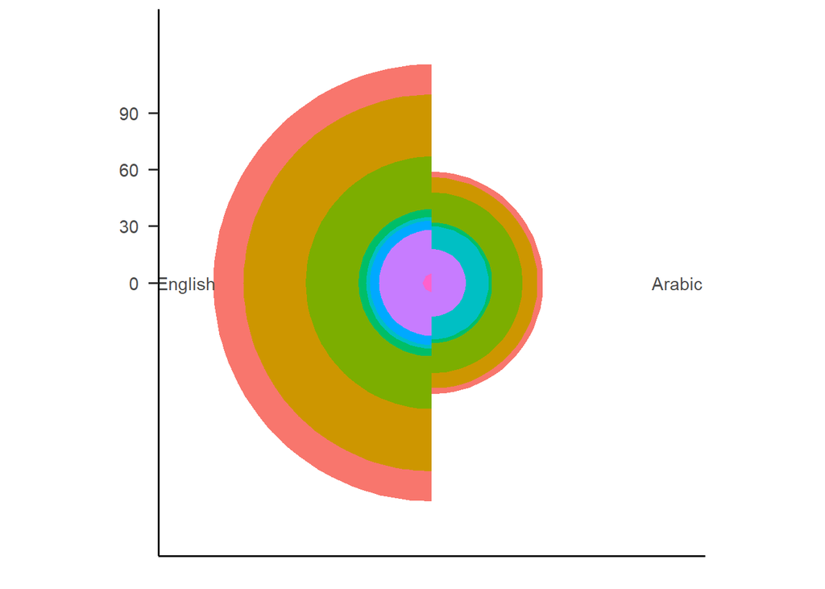

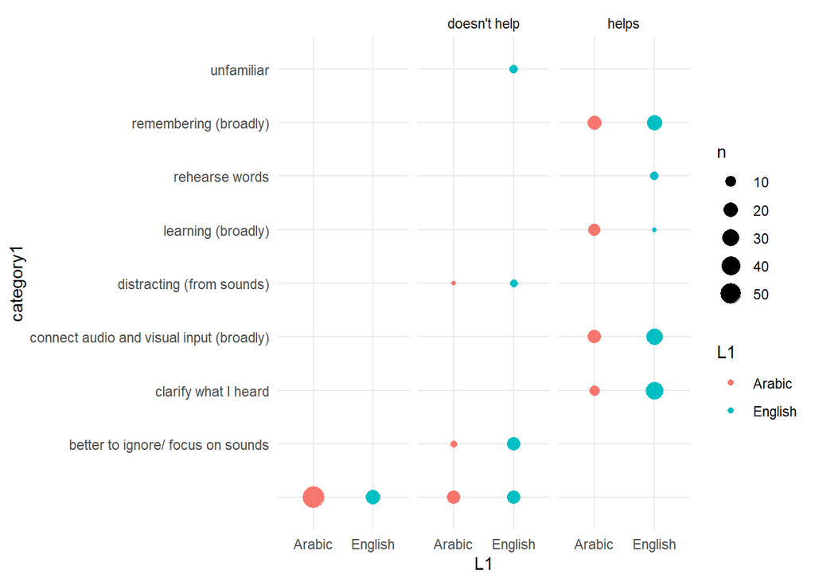

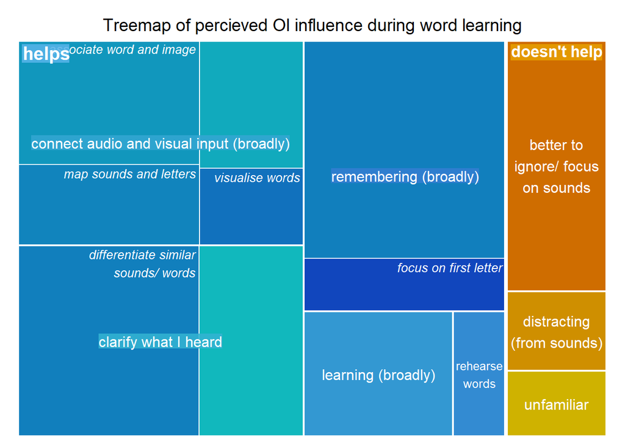

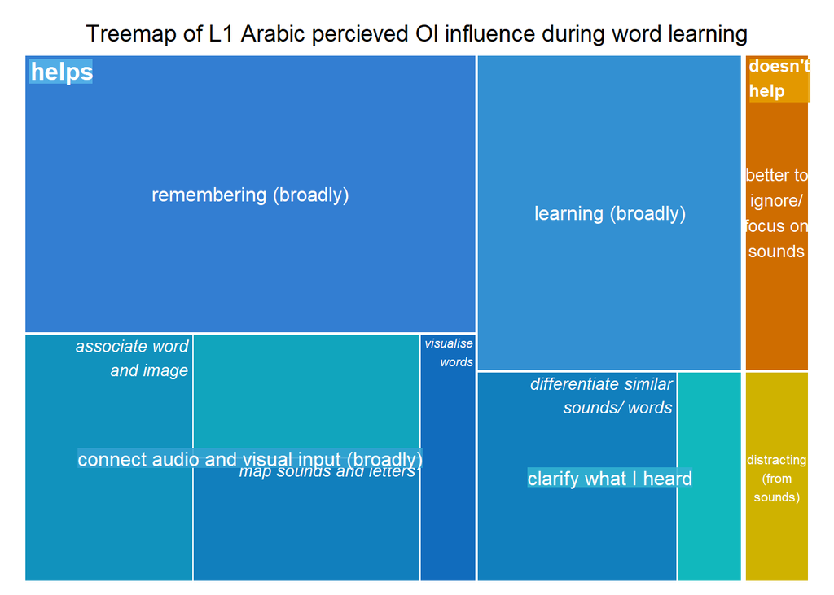

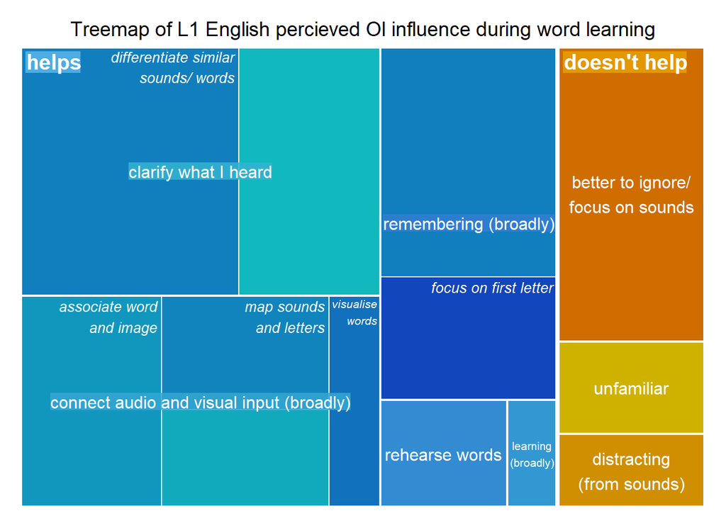

create new dataset removing responses that couldn’t be coded for beliefs about OI importance.

```r
OI_import1 <- OI_infl_QCA %>%
  filter(category2 != "")
```

Summary Statistics

| L1 Variable | Arabic N | Arabic Percent | English N | English Percent |
| --- | --- | --- | --- | --- |
| resp_lang2 | 121 |  | 133 |  |
| … | 0 | 0% | 0 | 0% |
| … - | 0 | 0% | 0 | 0% |
| … Arabic | 60 | 49.6% | 0 | 0% |
| … English | 61 | 50.4% | 133 | 100% |
| OI.importance | 121 |  | 133 |  |
| … #N/A | 0 | 0% | 0 | 0% |
| … no | 9 | 7.4% | 33 | 24.8% |
| … yes | 112 | 92.6% | 100 | 75.2% |
| category2 | 121 |  | 133 |  |
| … | 0 | 0% | 0 | 0% |
| … (about the experiment) | 5 | 4.1% | 11 | 8.3% |
| … clarifying and consolidating new language | 47 | 38.8% | 54 | 40.6% |
| … it’s too much to process | 4 | 3.3% | 7 | 5.3% |
| … learning style | 3 | 2.5% | 9 | 6.8% |
| … memorisation | 16 | 13.2% | 0 | 0% |
| … previous (language) learning | 1 | 0.8% | 4 | 3% |
| … remembering (broadly) | 17 | 14% | 10 | 7.5% |
| … sound is more important/ beneficial | 2 | 1.7% | 10 | 7.5% |
| … speed of learning | 6 | 5% | 0 | 0% |
| … spelling doesn’t reflect pronunciation | 2 | 1.7% | 8 | 6% |
| … visual association | 11 | 9.1% | 12 | 9% |
| … visualisation | 7 | 5.8% | 8 | 6% |
| subcategory2 | 121 |  | 133 |  |
| … | 83 | 68.6% | 85 | 63.9% |
| … correct comprehension | 15 | 12.4% | 25 | 18.8% |
| … correct production | 17 | 14% | 11 | 8.3% |
| … decoding sounds and letters | 6 | 5% | 12 | 9% |

create another new dataset removing responses that related to the experiment and not learning in general.

```r
OI_import2  <- OI_import1  %>%
  filter(category2 != "(about the experiment)")

OI_importance_tb2 <- select(OI_import2,resp_lang2, OI.importance, category2,subcategory2, L1)

st(OI_importance_tb2, group = "L1")
```

Summary Statistics

| L1 Variable | Arabic N | Arabic Percent | English N | English Percent |
| --- | --- | --- | --- | --- |
| resp_lang2 | 116 |  | 122 |  |
| … | 0 | 0% | 0 | 0% |
| … - | 0 | 0% | 0 | 0% |
| … Arabic | 56 | 48.3% | 0 | 0% |
| … English | 60 | 51.7% | 122 | 100% |
| OI.importance | 116 |  | 122 |  |
| … #N/A | 0 | 0% | 0 | 0% |
| … no | 9 | 7.8% | 29 | 23.8% |
| … yes | 107 | 92.2% | 93 | 76.2% |
| category2 | 116 |  | 122 |  |
| … | 0 | 0% | 0 | 0% |
| … (about the experiment) | 0 | 0% | 0 | 0% |
| … clarifying and consolidating new language | 47 | 40.5% | 54 | 44.3% |
| … it’s too much to process | 4 | 3.4% | 7 | 5.7% |
| … learning style | 3 | 2.6% | 9 | 7.4% |
| … memorisation | 16 | 13.8% | 0 | 0% |
| … previous (language) learning | 1 | 0.9% | 4 | 3.3% |
| … remembering (broadly) | 17 | 14.7% | 10 | 8.2% |
| … sound is more important/ beneficial | 2 | 1.7% | 10 | 8.2% |
| … speed of learning | 6 | 5.2% | 0 | 0% |
| … spelling doesn’t reflect pronunciation | 2 | 1.7% | 8 | 6.6% |
| … visual association | 11 | 9.5% | 12 | 9.8% |
| … visualisation | 7 | 6% | 8 | 6.6% |
| subcategory2 | 116 |  | 122 |  |
| … | 79 | 68.1% | 74 | 60.7% |
| … correct comprehension | 15 | 12.9% | 25 | 20.5% |
| … correct production | 16 | 13.8% | 11 | 9% |
| … decoding sounds and letters | 6 | 5.2% | 12 | 9.8% |

Treemaps for RQ 2.2

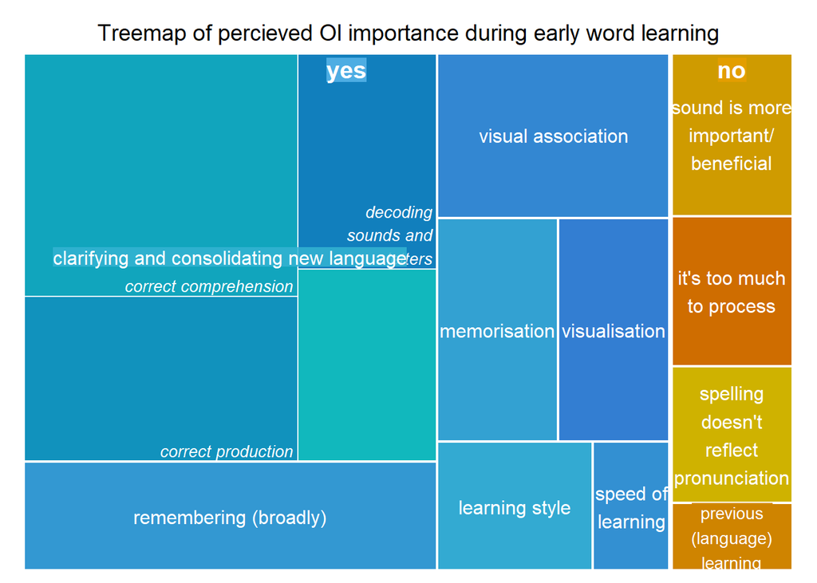

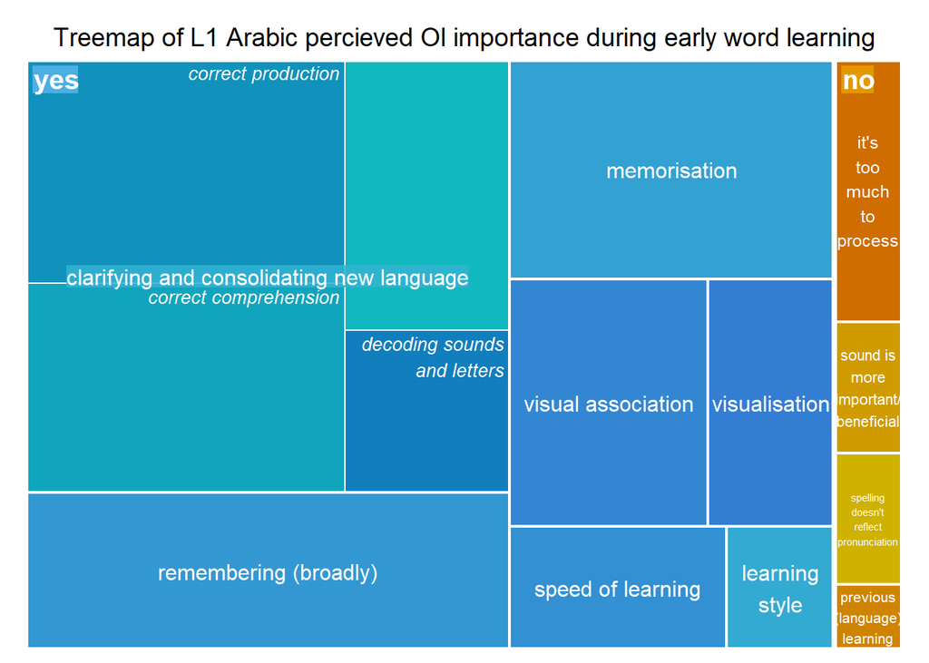

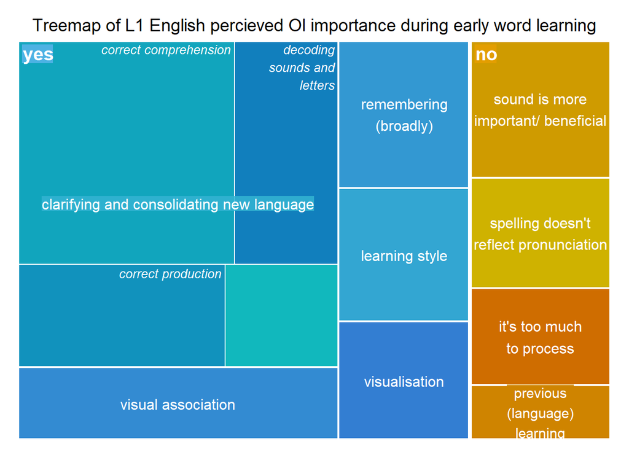